# Narrating the American Drug Abuse Crisis through Litigations of Pharmaceutical Companies between 2000 and 2019

Hajra Sohail

2022-07-02

# Abstract

The pharmaceutical industry holds a lot of influence over America- by working with researchers, governments, and health officials, Big Pharma companies are able to put many novel therapeutics onto the market that benefit many parties. However, due to a lack of drug regulation, increase in lobbying, and fraudulent practices, the way many common, lifesaving drugs are priced and marketed has led to a drug abuse crisis. Evidence has shown that there is an “impact of physician-pharmaceutical industry interactions on increased prescribing frequency in favor of the promoted drugs, lower prescribing quality, and unnecessarily increased costs, which may have negative implications on patient care” (Fadlallah, 2016).

For this final project, I want to explore the breakdown of legal proceedings against the top pharmaceutical companies by examining the distribution of cases by year, type of offense, and the description of each legal case. For example, one important legal event was regarding Purdue Pharma, who played a large role in initiating the opioid crisis in the United States. “Estimates in 2017 suggest 40.5 million people were dependent upon opioids and 109,500 people died from opioid overdose” (Degenhardt, 2019). “The epidemic of medical drug use [is] escalating with Americans using 80% of the world supply of all opioids and 99% of hydrocodine (Manchikanti, 2007). Looking at which types of lawsuits were settled during this 20-year time period could indicate why there are notable trends in death rates by type of drug and opioid prescribing rates by geography.

# Question & Problem

Are prosecutions against pharmaceutical companies correlated with prescribing rates and deaths of drugs between 2000 and 2019?

# Scope

An analysis of drug deaths and makeup of lawsuits was done on a national level. Supplemental pharmaceutical data that is on an international scale was used to compare companies.

# Methods

A scatterplot of the top 50 pharmaceutical companies was also analyzed, which lists each corporation’s prescription sales and R&D spending in 2020 published by Pharmaceutical Executive. This plot connected the five companies with the greatest amount of penalties in the Violations Tracker datasheet. Two linear regression models for each dataset was also created.

# Results

## Exploring Legal Cases

Breaking down the Good Jobs Tracker Violations dataset shows that between 2000 and 2019, there have been a large amount of legal persecutions against pharmaceutical companies around 2010. The number of cases seem to drop off after 2013.

The top three primary offenses within this time span are:

1. False Claims Act Violations
2. Environmental Violations
3. Drug/Medical Equipment Safety Violations

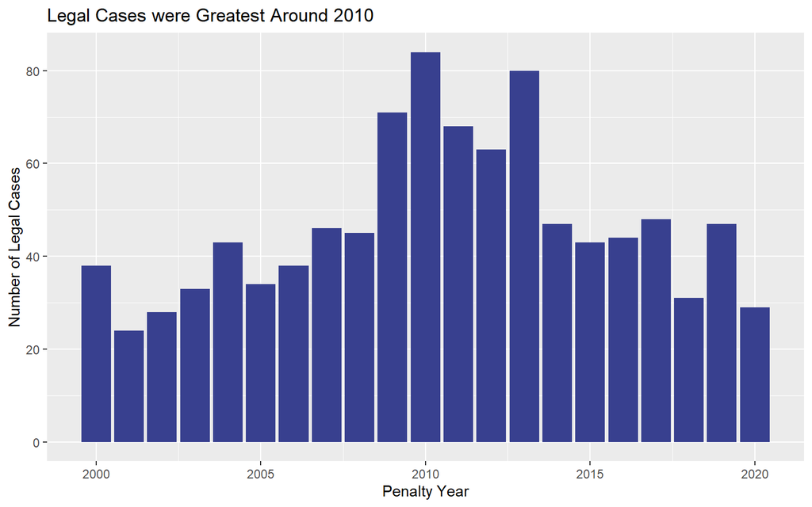

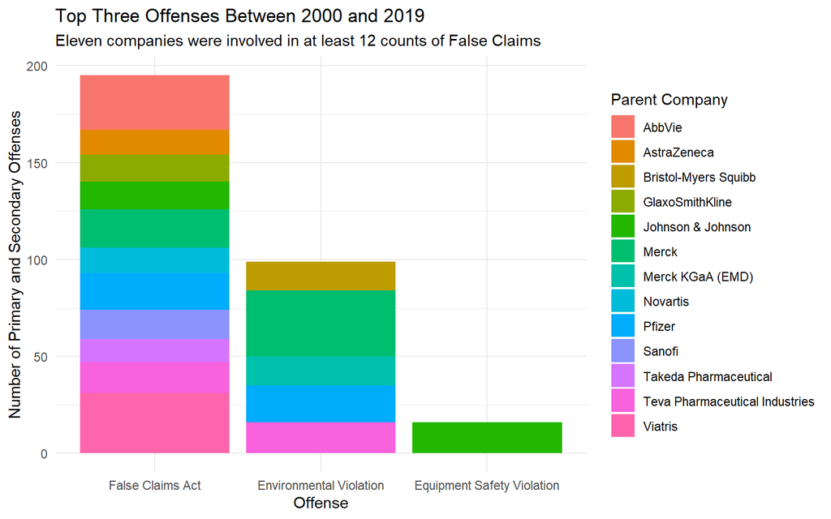

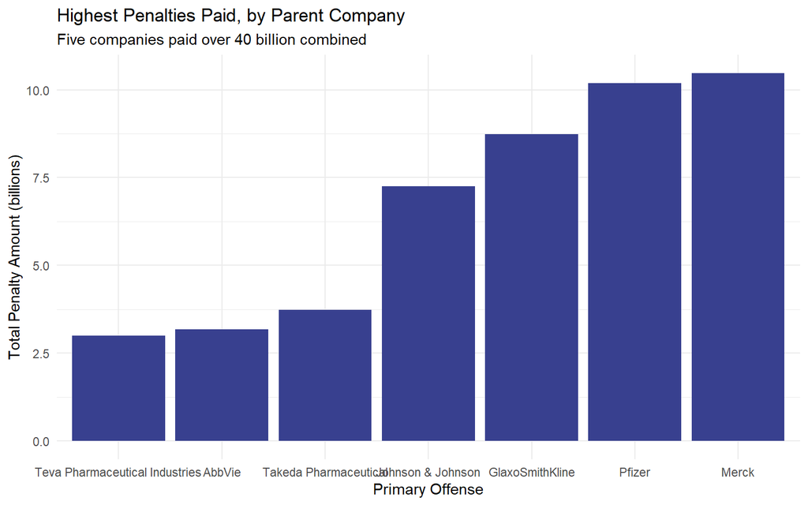

The False Claim Act refers to a federal law that prevents fraudulent acts within the United States healthcare system in clinical and research settings. Violations can include mismarketing of products, billing for services not performed, and inflating costs for Medicaid.

Viatris has 31 offenses of False Claims Act Violations alone. The largest penalty paid was in August 2017, when Viatris ‘agreed to pay $465 million to resolve claims that they violated the False Claims Act by knowingly misclassifying EpiPen as a generic drug to avoid paying rebates owed primarily to Medicaid’ (www.violationtracker.goodjobsfirst.org).

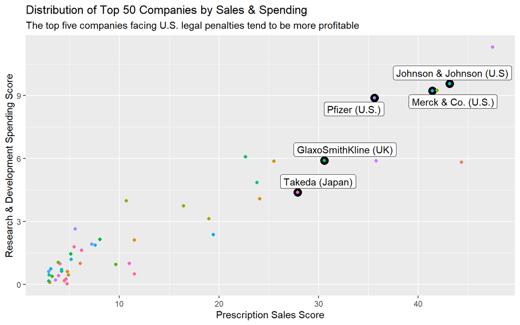

Linear regression model information for all fifty companies:

```
##
## Call:
## lm(formula = rdspending ~ pres_sales, data = toppharmacompanies)
##
## Residuals:
##      Min       1Q   Median       3Q      Max
## -3.07120 -0.56316 -0.06258  0.54469  1.93652
##
## Coefficients:
##              Estimate Std. Error t value Pr(>|t|)
## (Intercept) -0.121914   0.206616   -0.59    0.558
## pres_sales   0.203498   0.009977   20.40   <2e-16 ***
## ---
## Signif. codes:  0 '***' 0.001 '**' 0.01 '*' 0.05 '.' 0.1 ' ' 1
##
## Residual standard error: 0.983 on 46 degrees of freedom
##   (2 observations deleted due to missingness)
## Multiple R-squared:  0.9004, Adjusted R-squared:  0.8983
## F-statistic:   416 on 1 and 46 DF,  p-value: < 2.2e-16
```

Linear regression model information for top five companies:

```
##
## Call:
## lm(formula = rdspending ~ pres_sales, data = overlaytop5)
##
## Residuals:
##         1         2         3         4         5
##  0.004128 -0.464537 -0.233795  1.327974 -0.633769
##
## Coefficients:
##             Estimate Std. Error t value Pr(>|t|)
## (Intercept) -4.12518    2.46458  -1.674    0.193
## pres_sales   0.32792    0.06803   4.820    0.017 *
## ---
## Signif. codes:  0 '***' 0.001 '**' 0.01 '*' 0.05 '.' 0.1 ' ' 1
##
## Residual standard error: 0.901 on 3 degrees of freedom
## Multiple R-squared:  0.8856, Adjusted R-squared:  0.8475
## F-statistic: 23.23 on 1 and 3 DF,  p-value: 0.01702
```

Connecting the top five companies paying penalties to the top fifty international pharmaceutical corporations shows that these litigations are targeting more profitable companies. It could be inferred that the money invested in R&D spending could have also included illegal acts such as mismarketing of products, which leads to an increase of prescription sales.

## Exploring Drug Deaths

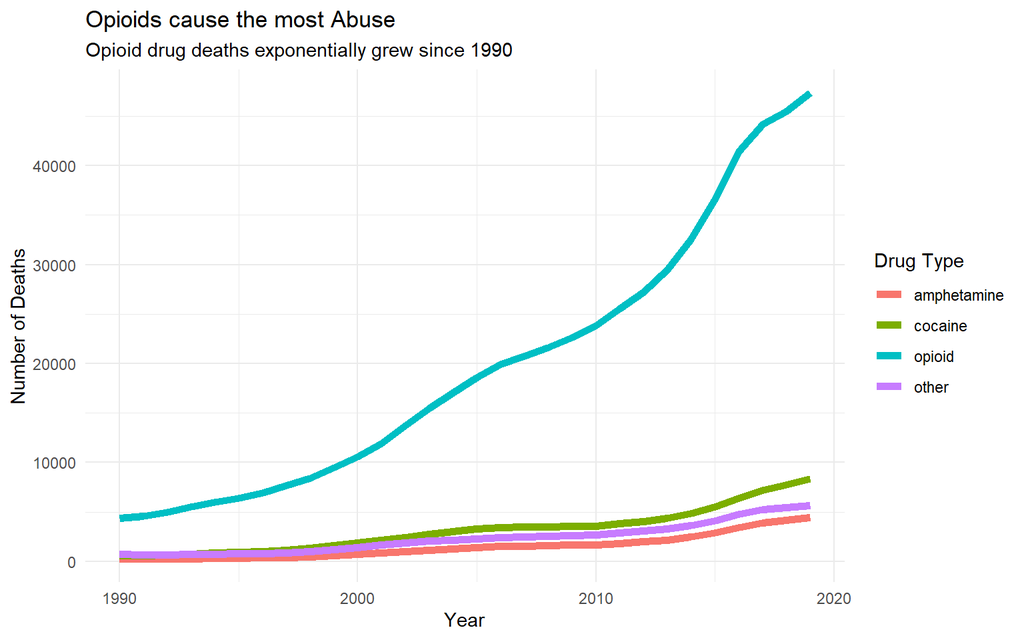

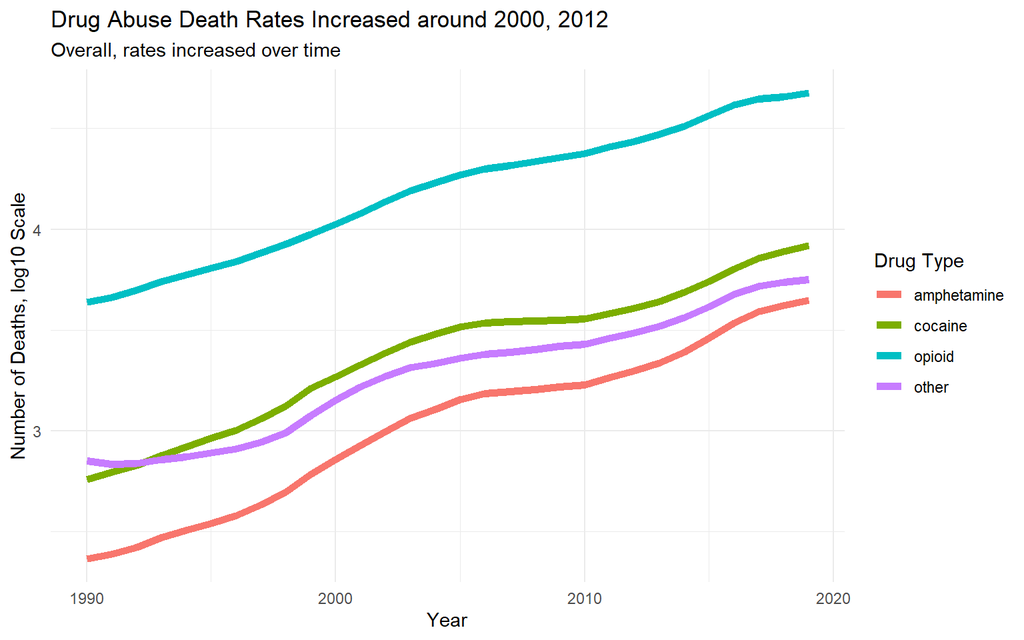

According to [the CDC](https://www.cdc.gov/drugoverdose/deaths/index.html), there were three waves of opioid overdose deaths: the first wave started in 1999 when there was an increase of prescribed opioids.

The second wave was around 2010, when there were rapid overdose deaths involving heroin.

The third wave was around 2013, as there was an increase of deaths due to synthetic opioids (fentanyl). It is important to note that many of these drug deaths may be an indirect result of risk factors, such as underlying health issues.

## Opioid Dispensing Rates

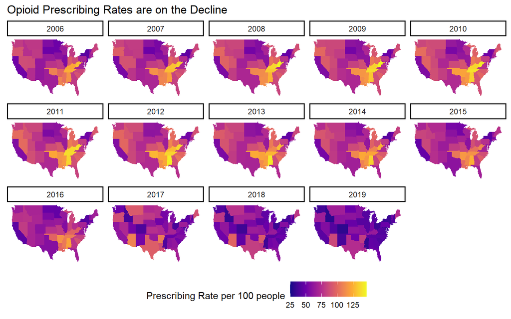

It seems that the South were prescribed more opioid drugs than other regions. Although there were not sufficient data regarding state cases in this area, it could be inferred that other state cases, such as ones in New York and Oregon, could have led to pharmaceutical companies to change their practices on a national scale to prevent further lawsuits.

Below is a description of each legal case between 2000 and 2019 that refers to fueling the opioid crisis:

[output not shown]

# Main Conclusions

It was interesting to see that indeed, the companies that paid more in penalties (Takeda, GlaxoSmithKline, Johnson & Johnson, Pfizer, & Merck) had more revenue. To study this relationship further, perhaps numerical modeling of each corporation’s use of spending versus penalties could be conducted.

I expected to see more compelling data regarding the role of drug companies in beginning the drug abuse crisis, such as Purdue Pharma and their long-acting opioid Oxycontin. However, major court rulings for Purdue Pharma occurred in 2020, which was outside of the timeframe selected for this analysis.

In the future, I believe there should be more concise and detailed studies on specific drugs that were mismarketed and how these actions affect prescribing rates and drug deaths. Although detailed descriptions were included in the Violations Tracker data, a categorical variable that listed the drug involved may have provided a different perspective on the offenses ruled.

# References

Degenhardt, Louisa et al. “Global patterns of opioid use and dependence: harms to populations, interventions, and future action.” Lancet (London, England) vol. 394,10208 (2019): 1560-1579. doi:10.1016/S0140-6736(19)32229-9.

Fadlallah, Racha et al. “Knowledge, Beliefs and Attitudes of Patients and the General Public towards the Interactions of Physicians with the Pharmaceutical and the Device Industry: A Systematic Review.” PloS one vol. 11,8 e0160540. 24 Aug. 2016, doi:10.1371/journal.pone.0160540.

Manchikanti, Laxmaiah. “National drug control policy and prescription drug abuse: facts and fallacies.” Pain Physician, 2007 May, https://pubmed.ncbi.nlm.nih.gov/17525776/

Ritchie, Hannah and Roser, Max. “Opioids, cocaine, cannabis and illicit drugs”. Our World in Data, 2018, https://ourworldindata.org/illicit-drug-use. Accessed 17 Apr. 2022.

“Top 50 pharmaceutical companies - Rx sales and R&D spending 2020”. Pharmaceutical Executive. June 2021, https://www.statista.com/statistics/273029/top-10-pharmaceutical-companies-sales-and-rundd-spending-in-2010/. Accessed 16 Apr. 2022.

“US Opioid Dispensing Rate Map”. Centers for Disease Control and Prevention, 10 Nov. 2021, https://www.cdc.gov/drugoverdose/rxrate-maps/index.html. Accessed 21 Apr. 2022.

“Violation Tracker Industry Summary Page”. Good Jobs First, 2022, https://violationtracker.goodjobsfirst.org/industry/pharmaceuticals. Accessed 17 Apr. 2022.